# NSNEQ_Moon_Example

Peder M Isager

2017 M10 16

# Example of an effect that is neither statistically significant nor equivalent

1. The data indicate the absence of a meaningful effect, and we can accept the null hypothesis.
2. The data are not sensitive enough to tell us whether a meaningful effect is present or absent.

In order to distinguish between these two hypotheses, we first need to define a SESOI (and thus, our equivalence bounds). Let us imagine that we consult a teacher about the test, and discover that that grades for this test are set at every 6.25% increase in correct answers (F = 0% to 6.25% … A+ = 93.75% to 100%). We can decide that we are only interested in test differences so far as they correspond to at least a 1 gradepoint increase or decrease. Thus, our SESOI becomes 6.25%, or 0.0625.

Using the TOSTtwo function in the TOSTER package in R, we can then calculate the TOST by insterting the summary statistics from Moon & Roeder’s (2014) data, assuming an aplha of 0.05, and using +/- the SESOI of 0.0625 as our equivalence bounds.

```r
#  We first load the relevant datafile into R
moon.data    <- read.csv("NSNEQ_Moon_Example_data.csv")

#  We then calculate the summary statistics from the data that we need in the TOST calculation below
mean.asian   <- mean(moon.data$accuracy[moon.data$identity_salience == 1])
mean.control <- mean(moon.data$accuracy[moon.data$identity_salience == 2])
sd.asian     <- sd(moon.data$accuracy[moon.data$identity_salience == 1])
sd.control   <- sd(moon.data$accuracy[moon.data$identity_salience == 2])
n.asian      <- sum(moon.data$identity_salience == 1)
n.control    <- sum(moon.data$identity_salience == 2)

#  We can now run the TOST!
#  Performing the TOST using the 'TOSTtwo.raw' function allows us to specify equivalence bounds in raw values
tost <- TOSTER::TOSTtwo.raw(m1  = mean.asian,
                            m2  = mean.control,
                            sd1 = sd.asian,
                            sd2 = sd.control,
                            n1  = n.asian,
                            n2  = n.control,
                            low_eqbound  = -0.0625,
                            high_eqbound =  0.0625,
                            alpha = .05)
```

```
## Using alpha = 0.05 Welch's t-test was non-significant, t(97.76702) = -1.07647, p = 0.2843664
```

```
##
## Using alpha = 0.05 the equivalence test based on Welch's t-test  was non-significant, t(97.76702) = 0.7054677, p = 0.2410984
```

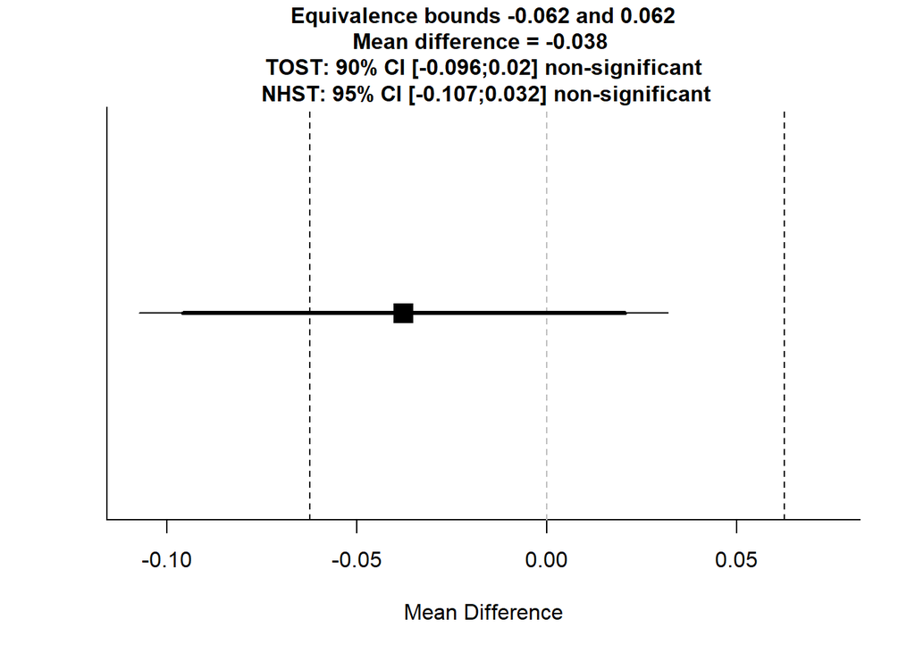

```
## TOST results:
##   t-value 1 p-value 1 t-value 2   p-value 2       df
## 1 0.7054677 0.2410984 -2.858407 0.002601883 97.76702
##
## Equivalence bounds (raw scores):
##   low bound raw high bound raw
## 1       -0.0625         0.0625
##
## TOST confidence interval:
##   Lower Limit 90% CI raw Upper Limit 90% CI raw
## 1             -0.0960001              0.0204875
```

We find that the TOST is non-significant, t(97.77) = 0.71, p = 0.24. Thus, we cannot reject the possibility that the true effect really is larger than our SESOI.